# Bankruptcy Predictions

Running a business is a complex thing, especially on the finacial side. So, if a business goes into bankruptcy it can be often hard to figure out what went wrong. This means that it can be hard for companies to see the signs of bankruptcy before it's too late. Therefore I will be using the [Company Bankruptcy Predictions](https://www.kaggle.com/datasets/fedesoriano/company-bankruptcy-prediction) data set in order to create a model that predicts whether or not a company goes bankrupt before signs become obvious.

```r
### Importing Libraries needed for the problem
library(e1071)
library(glmnet)
library(pROC)
```

### Importing and Cleaning the Data

Much like every data sceince problem the process begins first by importing and cleaning the data.

```r
### Importing the data set
bnk = read.csv('bankruptcy.csv')
dim(bnk)
head(bnk)
```

1. 6819

2. 96

A data.frame: 6 × 96

|  | Bankrupt. <int> | ROA.C..before.interest.and.depreciation.before.interest <dbl> | ROA.A..before.interest.and...after.tax <dbl> | ROA.B..before.interest.and.depreciation.after.tax <dbl> | Operating.Gross.Margin <dbl> | Realized.Sales.Gross.Margin <dbl> | Operating.Profit.Rate <dbl> | Pre.tax.net.Interest.Rate <dbl> | After.tax.net.Interest.Rate <dbl> | Non.industry.income.and.expenditure.revenue <dbl> | ⋯ | Net.Income.to.Total.Assets <dbl> | Total.assets.to.GNP.price <dbl> | No.credit.Interval <dbl> | Gross.Profit.to.Sales <dbl> | Net.Income.to.Stockholder.s.Equity <dbl> | Liability.to.Equity <dbl> | Degree.of.Financial.Leverage..DFL. <dbl> | Interest.Coverage.Ratio..Interest.expense.to.EBIT. <dbl> | Net.Income.Flag <int> | Equity.to.Liability <dbl> |
| --- | --- | --- | --- | --- | --- | --- | --- | --- | --- | --- | --- | --- | --- | --- | --- | --- | --- | --- | --- | --- | --- |
| 1 | 1 | 0.3705943 | 0.4243894 | 0.4057498 | 0.6014572 | 0.6014572 | 0.9989692 | 0.7968871 | 0.8088094 | 0.3026464 | ⋯ | 0.7168453 | 0.009219440 | 0.6228790 | 0.6014533 | 0.8278902 | 0.2902019 | 0.02660063 | 0.5640501 | 1 | 0.01646874 |
| 2 | 1 | 0.4642909 | 0.5382141 | 0.5167300 | 0.6102351 | 0.6102351 | 0.9989460 | 0.7973802 | 0.8093007 | 0.3035564 | ⋯ | 0.7952971 | 0.008323302 | 0.6236517 | 0.6102365 | 0.8399693 | 0.2838460 | 0.26457682 | 0.5701749 | 1 | 0.02079431 |
| 3 | 1 | 0.4260713 | 0.4990188 | 0.4722951 | 0.6014500 | 0.6013635 | 0.9988574 | 0.7964034 | 0.8083875 | 0.3020352 | ⋯ | 0.7746697 | 0.040002853 | 0.6238410 | 0.6014493 | 0.8367743 | 0.2901885 | 0.02655472 | 0.5637061 | 1 | 0.01647411 |
| 4 | 1 | 0.3998440 | 0.4512647 | 0.4577333 | 0.5835411 | 0.5835411 | 0.9986997 | 0.7969670 | 0.8089656 | 0.3033495 | ⋯ | 0.7395545 | 0.003252475 | 0.6229287 | 0.5835376 | 0.8346971 | 0.2817212 | 0.02669663 | 0.5646634 | 1 | 0.02398233 |
| 5 | 1 | 0.4650222 | 0.5384322 | 0.5222978 | 0.5987835 | 0.5987835 | 0.9989731 | 0.7973661 | 0.8093037 | 0.3034750 | ⋯ | 0.7950159 | 0.003877563 | 0.6235207 | 0.5987815 | 0.8399727 | 0.2785138 | 0.02475185 | 0.5756166 | 1 | 0.03549020 |
| 6 | 1 | 0.3886803 | 0.4151766 | 0.4191338 | 0.5901714 | 0.5902507 | 0.9987581 | 0.7969032 | 0.8087706 | 0.3031158 | ⋯ | 0.7104205 | 0.005277875 | 0.6226046 | 0.5901723 | 0.8299390 | 0.2850871 | 0.02667537 | 0.5645383 | 1 | 0.01953448 |

```r
### Checking for any NA values
sum(is.na(bnk))
```

0

Since there are no NA values in our data set we are good to go on to our nex step.

### Creating the Train and Test Sets

So in order to create our model we need to divide the data set into a train set and a test set. In order to maintain ensure the replicability of our work we will set the sample seed to the value 57. After that we will take 80% of the data from the 'bnk' data frame for the train data frame. The remaining data will go into the test data frame.

```r
### Getting the sample
set.seed(57)

smp = sample(1:nrow(bnk), size = 0.8 * nrow(bnk), replace = FALSE)
```

```r
### Creating the train and test data frames
train = bnk[smp, ]
test = bnk[-smp,]
head(train)
head(test)
```

A data.frame: 6 × 96

|  | Bankrupt. <int> | ROA.C..before.interest.and.depreciation.before.interest <dbl> | ROA.A..before.interest.and...after.tax <dbl> | ROA.B..before.interest.and.depreciation.after.tax <dbl> | Operating.Gross.Margin <dbl> | Realized.Sales.Gross.Margin <dbl> | Operating.Profit.Rate <dbl> | Pre.tax.net.Interest.Rate <dbl> | After.tax.net.Interest.Rate <dbl> | Non.industry.income.and.expenditure.revenue <dbl> | ⋯ | Net.Income.to.Total.Assets <dbl> | Total.assets.to.GNP.price <dbl> | No.credit.Interval <dbl> | Gross.Profit.to.Sales <dbl> | Net.Income.to.Stockholder.s.Equity <dbl> | Liability.to.Equity <dbl> | Degree.of.Financial.Leverage..DFL. <dbl> | Interest.Coverage.Ratio..Interest.expense.to.EBIT. <dbl> | Net.Income.Flag <int> | Equity.to.Liability <dbl> |
| --- | --- | --- | --- | --- | --- | --- | --- | --- | --- | --- | --- | --- | --- | --- | --- | --- | --- | --- | --- | --- | --- |
| 849 | 0 | 0.4885682 | 0.5286197 | 0.5440869 | 0.6022644 | 0.6022644 | 0.9989984 | 0.7973628 | 0.8092933 | 0.3034162 | ⋯ | 0.7935210 | 0.0008802698 | 0.6251013 | 0.6022658 | 0.8398665 | 0.2783875 | 0.02630429 | 0.5608536 | 1 | 0.03635116 |
| 2532 | 0 | 0.4722371 | 0.5541867 | 0.5410354 | 0.6114098 | 0.6114098 | 0.9990096 | 0.7974777 | 0.8096541 | 0.3035937 | ⋯ | 0.8083500 | 0.0050873803 | 0.6214210 | 0.6114069 | 0.8407094 | 0.2758435 | 0.02725285 | 0.5666905 | 1 | 0.09352044 |
| 2699 | 0 | 0.4897870 | 0.5472089 | 0.5379303 | 0.6277908 | 0.6277908 | 0.9990094 | 0.7973951 | 0.8093212 | 0.3034498 | ⋯ | 0.7985997 | 0.0006771514 | 0.6236947 | 0.6277911 | 0.8403095 | 0.2826864 | 0.03072391 | 0.5691300 | 1 | 0.02232432 |
| 2478 | 0 | 0.5052893 | 0.5731574 | 0.5555972 | 0.5957422 | 0.5957422 | 0.9989819 | 0.7974647 | 0.8093753 | 0.3036289 | ⋯ | 0.8179516 | 0.0811854212 | 0.6229795 | 0.5957394 | 0.8417948 | 0.2795573 | 0.02691299 | 0.5656793 | 1 | 0.03008475 |
| 6760 | 0 | 0.4299712 | 0.4730702 | 0.4692435 | 0.5663025 | 0.5661800 | 0.9982320 | 0.7965875 | 0.8084681 | 0.3036650 | ⋯ | 0.7583393 | 0.0005388490 | 0.6224677 | 0.5663040 | 0.8377555 | 0.2768217 | 0.02673812 | 0.5648921 | 1 | 0.05545917 |
| 531 | 0 | 0.4832058 | 0.5324357 | 0.5268483 | 0.6065164 | 0.6065164 | 0.9989616 | 0.7974938 | 0.8093281 | 0.3037225 | ⋯ | 0.7969476 | 0.0012076799 | 0.6291136 | 0.6065122 | 0.8400955 | 0.2760318 | 0.02679893 | 0.5651952 | 1 | 0.08191116 |

A data.frame: 6 × 96

|  | Bankrupt. <int> | ROA.C..before.interest.and.depreciation.before.interest <dbl> | ROA.A..before.interest.and...after.tax <dbl> | ROA.B..before.interest.and.depreciation.after.tax <dbl> | Operating.Gross.Margin <dbl> | Realized.Sales.Gross.Margin <dbl> | Operating.Profit.Rate <dbl> | Pre.tax.net.Interest.Rate <dbl> | After.tax.net.Interest.Rate <dbl> | Non.industry.income.and.expenditure.revenue <dbl> | ⋯ | Net.Income.to.Total.Assets <dbl> | Total.assets.to.GNP.price <dbl> | No.credit.Interval <dbl> | Gross.Profit.to.Sales <dbl> | Net.Income.to.Stockholder.s.Equity <dbl> | Liability.to.Equity <dbl> | Degree.of.Financial.Leverage..DFL. <dbl> | Interest.Coverage.Ratio..Interest.expense.to.EBIT. <dbl> | Net.Income.Flag <int> | Equity.to.Liability <dbl> |
| --- | --- | --- | --- | --- | --- | --- | --- | --- | --- | --- | --- | --- | --- | --- | --- | --- | --- | --- | --- | --- | --- |
| 3 | 1 | 0.4260713 | 0.4990188 | 0.4722951 | 0.6014500 | 0.6013635 | 0.9988574 | 0.7964034 | 0.8083875 | 0.3020352 | ⋯ | 0.7746697 | 0.040002853 | 0.6238410 | 0.6014493 | 0.8367743 | 0.2901885 | 0.02655472 | 0.5637061 | 1 | 0.01647411 |
| 13 | 0 | 0.4911520 | 0.5515700 | 0.5433910 | 0.6081307 | 0.6081379 | 0.9990449 | 0.7974289 | 0.8093443 | 0.3034349 | ⋯ | 0.8032602 | 0.008232490 | 0.6235776 | 0.6081254 | 0.8407024 | 0.2811134 | 0.02747972 | 0.5671463 | 1 | 0.02528172 |
| 21 | 0 | 0.4852533 | 0.5455735 | 0.5346646 | 0.6221767 | 0.6222560 | 0.9990655 | 0.7975217 | 0.8094058 | 0.3035538 | ⋯ | 0.8046390 | 0.014039384 | 0.6239224 | 0.6221772 | 0.8406386 | 0.2779879 | 0.02679378 | 0.5651709 | 1 | 0.03950700 |
| 29 | 0 | 0.5008531 | 0.5639446 | 0.5505648 | 0.6020265 | 0.6022932 | 0.9989824 | 0.7975029 | 0.8094001 | 0.3036949 | ⋯ | 0.8121003 | 0.001225311 | 0.6239102 | 0.6020270 | 0.8411160 | 0.2776644 | 0.02706672 | 0.5662006 | 1 | 0.04268190 |
| 36 | 0 | 0.4751621 | 0.5645443 | 0.5250281 | 0.6142781 | 0.6142781 | 0.9989734 | 0.7975198 | 0.8094438 | 0.3037430 | ⋯ | 0.8112574 | 0.080005795 | 0.6237088 | 0.6142772 | 0.8412521 | 0.2794736 | 0.02711461 | 0.5663392 | 1 | 0.03043123 |
| 37 | 0 | 0.4629259 | 0.5163541 | 0.5171048 | 0.6227028 | 0.6225299 | 0.9989974 | 0.7972450 | 0.8091902 | 0.3032125 | ⋯ | 0.7843849 | 0.007562958 | 0.6236310 | 0.6226977 | 0.8390289 | 0.2806732 | 0.02638528 | 0.5620162 | 1 | 0.02638736 |

Now we'll just double check the porportions are correct before we move on to the next step.

```r
## Checking the porportions
p1 = nrow(train) / nrow(bnk)
p2 = nrow(test) / nrow(bnk)
print(p1)
print(p2)
```

```
[1] 0.7999707
[1] 0.2000293
```

### Naive Bayes

We'll start of by doing naive bayes classification in on order to build our first model. The first step is convert the Bankrupt column to a 'factor' data type.

```r
### Converting Bankrupt
train$Bankrupt = as.factor(train$Bankrupt)
test$Bankrupt = as.factor(test$Bankrupt)
```

```r
### Checking our data
class(train$Bankrupt)
class(test$Bankrupt)
```

'factor'

'factor'

Since we've sucessfully converted the 'Bankrupt' column to the factor data type we are able to perform Naive Bayes classifaction.

```r
### Creating the modified data frame
trainEx = train[-1]
testEx = test[-1]
head(trainEx)
head(testEx)
```

A data.frame: 6 × 96

|  | ROA.C..before.interest.and.depreciation.before.interest <dbl> | ROA.A..before.interest.and...after.tax <dbl> | ROA.B..before.interest.and.depreciation.after.tax <dbl> | Operating.Gross.Margin <dbl> | Realized.Sales.Gross.Margin <dbl> | Operating.Profit.Rate <dbl> | Pre.tax.net.Interest.Rate <dbl> | After.tax.net.Interest.Rate <dbl> | Non.industry.income.and.expenditure.revenue <dbl> | Continuous.interest.rate..after.tax. <dbl> | ⋯ | Total.assets.to.GNP.price <dbl> | No.credit.Interval <dbl> | Gross.Profit.to.Sales <dbl> | Net.Income.to.Stockholder.s.Equity <dbl> | Liability.to.Equity <dbl> | Degree.of.Financial.Leverage..DFL. <dbl> | Interest.Coverage.Ratio..Interest.expense.to.EBIT. <dbl> | Net.Income.Flag <int> | Equity.to.Liability <dbl> | Bankrupt <fct> |
| --- | --- | --- | --- | --- | --- | --- | --- | --- | --- | --- | --- | --- | --- | --- | --- | --- | --- | --- | --- | --- | --- |
| 849 | 0.4885682 | 0.5286197 | 0.5440869 | 0.6022644 | 0.6022644 | 0.9989984 | 0.7973628 | 0.8092933 | 0.3034162 | 0.7816062 | ⋯ | 0.0008802698 | 0.6251013 | 0.6022658 | 0.8398665 | 0.2783875 | 0.02630429 | 0.5608536 | 1 | 0.03635116 | 0 |
| 2532 | 0.4722371 | 0.5541867 | 0.5410354 | 0.6114098 | 0.6114098 | 0.9990096 | 0.7974777 | 0.8096541 | 0.3035937 | 0.7817791 | ⋯ | 0.0050873803 | 0.6214210 | 0.6114069 | 0.8407094 | 0.2758435 | 0.02725285 | 0.5666905 | 1 | 0.09352044 | 0 |
| 2699 | 0.4897870 | 0.5472089 | 0.5379303 | 0.6277908 | 0.6277908 | 0.9990094 | 0.7973951 | 0.8093212 | 0.3034498 | 0.7815799 | ⋯ | 0.0006771514 | 0.6236947 | 0.6277911 | 0.8403095 | 0.2826864 | 0.03072391 | 0.5691300 | 1 | 0.02232432 | 0 |
| 2478 | 0.5052893 | 0.5731574 | 0.5555972 | 0.5957422 | 0.5957422 | 0.9989819 | 0.7974647 | 0.8093753 | 0.3036289 | 0.7816153 | ⋯ | 0.0811854212 | 0.6229795 | 0.5957394 | 0.8417948 | 0.2795573 | 0.02691299 | 0.5656793 | 1 | 0.03008475 | 0 |
| 6760 | 0.4299712 | 0.4730702 | 0.4692435 | 0.5663025 | 0.5661800 | 0.9982320 | 0.7965875 | 0.8084681 | 0.3036650 | 0.7806380 | ⋯ | 0.0005388490 | 0.6224677 | 0.5663040 | 0.8377555 | 0.2768217 | 0.02673812 | 0.5648921 | 1 | 0.05545917 | 0 |
| 531 | 0.4832058 | 0.5324357 | 0.5268483 | 0.6065164 | 0.6065164 | 0.9989616 | 0.7974938 | 0.8093281 | 0.3037225 | 0.7815872 | ⋯ | 0.0012076799 | 0.6291136 | 0.6065122 | 0.8400955 | 0.2760318 | 0.02679893 | 0.5651952 | 1 | 0.08191116 | 0 |

A data.frame: 6 × 96

|  | ROA.C..before.interest.and.depreciation.before.interest <dbl> | ROA.A..before.interest.and...after.tax <dbl> | ROA.B..before.interest.and.depreciation.after.tax <dbl> | Operating.Gross.Margin <dbl> | Realized.Sales.Gross.Margin <dbl> | Operating.Profit.Rate <dbl> | Pre.tax.net.Interest.Rate <dbl> | After.tax.net.Interest.Rate <dbl> | Non.industry.income.and.expenditure.revenue <dbl> | Continuous.interest.rate..after.tax. <dbl> | ⋯ | Total.assets.to.GNP.price <dbl> | No.credit.Interval <dbl> | Gross.Profit.to.Sales <dbl> | Net.Income.to.Stockholder.s.Equity <dbl> | Liability.to.Equity <dbl> | Degree.of.Financial.Leverage..DFL. <dbl> | Interest.Coverage.Ratio..Interest.expense.to.EBIT. <dbl> | Net.Income.Flag <int> | Equity.to.Liability <dbl> | Bankrupt <fct> |
| --- | --- | --- | --- | --- | --- | --- | --- | --- | --- | --- | --- | --- | --- | --- | --- | --- | --- | --- | --- | --- | --- |
| 3 | 0.4260713 | 0.4990188 | 0.4722951 | 0.6014500 | 0.6013635 | 0.9988574 | 0.7964034 | 0.8083875 | 0.3020352 | 0.7802839 | ⋯ | 0.040002853 | 0.6238410 | 0.6014493 | 0.8367743 | 0.2901885 | 0.02655472 | 0.5637061 | 1 | 0.01647411 | 1 |
| 13 | 0.4911520 | 0.5515700 | 0.5433910 | 0.6081307 | 0.6081379 | 0.9990449 | 0.7974289 | 0.8093443 | 0.3034349 | 0.7816091 | ⋯ | 0.008232490 | 0.6235776 | 0.6081254 | 0.8407024 | 0.2811134 | 0.02747972 | 0.5671463 | 1 | 0.02528172 | 0 |
| 21 | 0.4852533 | 0.5455735 | 0.5346646 | 0.6221767 | 0.6222560 | 0.9990655 | 0.7975217 | 0.8094058 | 0.3035538 | 0.7816543 | ⋯ | 0.014039384 | 0.6239224 | 0.6221772 | 0.8406386 | 0.2779879 | 0.02679378 | 0.5651709 | 1 | 0.03950700 | 0 |
| 29 | 0.5008531 | 0.5639446 | 0.5505648 | 0.6020265 | 0.6022932 | 0.9989824 | 0.7975029 | 0.8094001 | 0.3036949 | 0.7816362 | ⋯ | 0.001225311 | 0.6239102 | 0.6020270 | 0.8411160 | 0.2776644 | 0.02706672 | 0.5662006 | 1 | 0.04268190 | 0 |
| 36 | 0.4751621 | 0.5645443 | 0.5250281 | 0.6142781 | 0.6142781 | 0.9989734 | 0.7975198 | 0.8094438 | 0.3037430 | 0.7815514 | ⋯ | 0.080005795 | 0.6237088 | 0.6142772 | 0.8412521 | 0.2794736 | 0.02711461 | 0.5663392 | 1 | 0.03043123 | 0 |
| 37 | 0.4629259 | 0.5163541 | 0.5171048 | 0.6227028 | 0.6225299 | 0.9989974 | 0.7972450 | 0.8091902 | 0.3032125 | 0.7814720 | ⋯ | 0.007562958 | 0.6236310 | 0.6226977 | 0.8390289 | 0.2806732 | 0.02638528 | 0.5620162 | 1 | 0.02638736 | 0 |

```r
### Naive Bayes
mod = naiveBayes(x = trainEx, y = train$Bankrupt)
```

```r
### Getting Preditions
bnkPred = predict(mod, testEx)
```

Now that we've goten our bankruptcy predictions we're going to test the accuracy of our predictions using a confusion matrix.

```r
### Creating the Confusion Matrix
conf = table(testEx$Bankrupt, bnkPred)
conf
```

```
   bnkPred
       0    1
  0   84 1231
  1    0   49
```

```r
### Testing Accuracy
acc = (conf[1, 1] + conf[2, 2]) / sum(conf)
acc
```

0.0975073313782991

After we've finished performing our initial analysis. We see that we may have overfitted our model. This may due to the fact that our accurracy is `0.09750` Digging deeper our model had 100% accuracy predicting bankruptcy. However, that accuracy drops to `0.06387` when predicting a non bankrupt company. Therefore, we need to find a new way to create a model.

### What Went Wrong

So our model ended up predicting bankruptcy 93.8% of the time with less than 10% accuracy. So we need to figure out what went wrong in our initial model, and what we can do to refine it.

The first thing we need to do is to figure the porportion of bankrupt companies in our data set. We are doing this to check to see if we need to alter the sample going forward.

```r
### Getting the portion (Part 1)
table(bnk$Bankrupt)
```

```
   0    1
6599  220
```

```r
### Getting the portion (Part 2)
prt = 220/6819
prt
```

0.0322627951312509

We see that 3.22% of the data is companies that end up bankrupt. This means that our data set is unbalanced, and we need to rectify that in order to refine our model. The first step is to chop the portion of nonbankrupt companies (0) in half.

```r
### Grabbing the 0's
zs = list()

zs = which(bnk$Bankrupt == 0)
zs
```

1. 7

2. 8

3. 9

4. 10

5. 11

6. 12

7. 13

8. 14

9. 15

10. 16

11. 17

12. 18

13. 19

14. 20

15. 21

16. 22

17. 23

18. 24

19. 25

20. 26

21. 27

22. 28

23. 29

24. 32

25. 33

26. 34

27. 35

28. 36

29. 37

30. 38

31. 39

32. 40

33. 41

34. 42

35. 43

36. 44

37. 45

38. 46

39. 47

40. 48

41. 49

42. 50

43. 51

44. 52

45. 53

46. 54

47. 59

48. 60

49. 61

50. 62

51. 63

52. 64

53. 65

54. 66

55. 67

56. 68

57. 69

58. 70

59. 71

60. 72

61. 73

62. 74

63. 75

64. 76

65. 77

66. 78

67. 79

68. 80

69. 81

70. 83

71. 84

72. 85

73. 86

74. 87

75. 88

76. 89

77. 90

78. 91

79. 92

80. 93

81. 94

82. 95

83. 96

84. 97

85. 98

86. 99

87. 100

88. 101

89. 102

90. 103

91. 104

92. 105

93. 108

94. 109

95. 110

96. 111

97. 112

98. 113

99. 114

100. 115

101. 116

102. 117

103. 118

104. 119

105. 120

106. 121

107. 122

108. 123

109. 124

110. 125

111. 126

112. 127

113. 128

114. 129

115. 130

116. 131

117. 132

118. 134

119. 135

120. 136

121. 137

122. 138

123. 139

124. 140

125. 141

126. 142

127. 143

128. 144

129. 145

130. 146

131. 147

132. 148

133. 149

134. 150

135. 151

136. 152

137. 153

138. 154

139. 155

140. 156

141. 157

142. 158

143. 160

144. 161

145. 162

146. 163

147. 164

148. 165

149. 166

150. 167

151. 168

152. 169

153. 170

154. 171

155. 172

156. 173

157. 174

158. 175

159. 176

160. 177

161. 178

162. 179

163. 180

164. 181

165. 182

166. 183

167. 184

168. 188

169. 189

170. 190

171. 191

172. 192

173. 193

174. 194

175. 195

176. 196

177. 197

178. 198

179. 199

180. 200

181. 201

182. 202

183. 203

184. 204

185. 205

186. 206

187. 207

188. 208

189. 209

190. 210

191. 211

192. 212

193. 213

194. 214

195. 215

196. 216

197. 217

198. 218

199. 219

200. 220

201. ⋯

202. 6616

203. 6617

204. 6618

205. 6619

206. 6620

207. 6621

208. 6622

209. 6623

210. 6624

211. 6625

212. 6626

213. 6627

214. 6628

215. 6629

216. 6630

217. 6631

218. 6632

219. 6633

220. 6634

221. 6635

222. 6636

223. 6637

224. 6638

225. 6639

226. 6640

227. 6644

228. 6645

229. 6646

230. 6647

231. 6648

232. 6649

233. 6650

234. 6651

235. 6652

236. 6653

237. 6654

238. 6655

239. 6656

240. 6657

241. 6658

242. 6659

243. 6660

244. 6661

245. 6662

246. 6663

247. 6664

248. 6665

249. 6666

250. 6667

251. 6668

252. 6669

253. 6670

254. 6671

255. 6672

256. 6673

257. 6674

258. 6675

259. 6676

260. 6677

261. 6678

262. 6679

263. 6680

264. 6681

265. 6682

266. 6683

267. 6684

268. 6685

269. 6686

270. 6687

271. 6688

272. 6689

273. 6690

274. 6691

275. 6692

276. 6693

277. 6694

278. 6695

279. 6696

280. 6697

281. 6698

282. 6699

283. 6700

284. 6701

285. 6702

286. 6703

287. 6704

288. 6705

289. 6706

290. 6707

291. 6708

292. 6709

293. 6710

294. 6711

295. 6712

296. 6713

297. 6714

298. 6715

299. 6716

300. 6717

301. 6718

302. 6719

303. 6720

304. 6721

305. 6722

306. 6723

307. 6724

308. 6725

309. 6726

310. 6727

311. 6728

312. 6730

313. 6731

314. 6732

315. 6733

316. 6734

317. 6735

318. 6736

319. 6737

320. 6738

321. 6739

322. 6740

323. 6741

324. 6742

325. 6743

326. 6744

327. 6745

328. 6746

329. 6747

330. 6748

331. 6749

332. 6750

333. 6751

334. 6752

335. 6753

336. 6754

337. 6755

338. 6756

339. 6757

340. 6758

341. 6759

342. 6760

343. 6761

344. 6762

345. 6763

346. 6764

347. 6765

348. 6766

349. 6767

350. 6768

351. 6769

352. 6770

353. 6771

354. 6772

355. 6773

356. 6774

357. 6775

358. 6776

359. 6777

360. 6778

361. 6779

362. 6780

363. 6781

364. 6782

365. 6783

366. 6784

367. 6785

368. 6786

369. 6787

370. 6788

371. 6789

372. 6790

373. 6791

374. 6792

375. 6793

376. 6794

377. 6795

378. 6796

379. 6797

380. 6798

381. 6799

382. 6800

383. 6801

384. 6802

385. 6803

386. 6804

387. 6805

388. 6806

389. 6807

390. 6808

391. 6809

392. 6810

393. 6811

394. 6812

395. 6813

396. 6814

397. 6815

398. 6816

399. 6817

400. 6818

401. 6819

```r
### Getting a sample
set.seed(57)

samp = sample(zs, 3300)
samp
```

1. 889

2. 2689

3. 2860

4. 2634

5. 565

6. 3850

7. 5041

8. 4976

9. 2227

10. 2966

11. 4442

12. 3401

13. 1848

14. 4944

15. 5396

16. 5980

17. 2596

18. 4923

19. 3151

20. 3433

21. 3495

22. 5827

23. 314

24. 2112

25. 6496

26. 1229

27. 5829

28. 3755

29. 3502

30. 2710

31. 5575

32. 3524

33. 4632

34. 5163

35. 43

36. 3414

37. 4242

38. 706

39. 4825

40. 4026

41. 4199

42. 2611

43. 2769

44. 3525

45. 41

46. 3270

47. 4363

48. 4218

49. 1391

50. 1529

51. 4463

52. 5159

53. 562

54. 5452

55. 5526

56. 3638

57. 35

58. 224

59. 5431

60. 4259

61. 5891

62. 3204

63. 6807

64. 2241

65. 4693

66. 638

67. 5138

68. 3593

69. 6005

70. 4176

71. 3308

72. 6355

73. 4791

74. 1095

75. 6281

76. 2854

77. 4799

78. 4955

79. 708

80. 3382

81. 3149

82. 5161

83. 5148

84. 3236

85. 2492

86. 5848

87. 5361

88. 6498

89. 206

90. 5648

91. 4562

92. 2445

93. 151

94. 1940

95. 6526

96. 5489

97. 1876

98. 2950

99. 2832

100. 2761

101. 924

102. 5441

103. 4330

104. 3343

105. 636

106. 26

107. 507

108. 2821

109. 3183

110. 991

111. 2745

112. 5122

113. 1918

114. 3453

115. 2967

116. 3733

117. 880

118. 4015

119. 6083

120. 4807

121. 2168

122. 5928

123. 4043

124. 3639

125. 2979

126. 117

127. 4616

128. 4848

129. 534

130. 4651

131. 5101

132. 3421

133. 2655

134. 4854

135. 4165

136. 220

137. 2381

138. 400

139. 2074

140. 5413

141. 2531

142. 6023

143. 3165

144. 5537

145. 3220

146. 852

147. 1885

148. 5931

149. 5868

150. 4619

151. 3089

152. 3690

153. 157

154. 6252

155. 1457

156. 2704

157. 4485

158. 150

159. 3949

160. 5541

161. 6000

162. 6352

163. 4970

164. 467

165. 1708

166. 4994

167. 6358

168. 5965

169. 4721

170. 3456

171. 4666

172. 6033

173. 2916

174. 1815

175. 2706

176. 2890

177. 5789

178. 6267

179. 1626

180. 5798

181. 5666

182. 671

183. 3415

184. 1371

185. 6415

186. 4644

187. 2157

188. 3939

189. 4611

190. 5721

191. 4604

192. 5360

193. 1190

194. 3335

195. 2591

196. 2558

197. 4876

198. 4830

199. 5377

200. 4814

201. ⋯

202. 2791

203. 6533

204. 3254

205. 2077

206. 147

207. 6560

208. 345

209. 5529

210. 967

211. 1956

212. 4823

213. 5654

214. 6591

215. 3924

216. 825

217. 770

218. 3239

219. 2526

220. 3119

221. 1604

222. 47

223. 4722

224. 4934

225. 4483

226. 3293

227. 2328

228. 582

229. 437

230. 1372

231. 855

232. 901

233. 4661

234. 83

235. 2668

236. 3315

237. 6318

238. 6449

239. 6320

240. 3811

241. 6133

242. 1746

243. 3344

244. 879

245. 4189

246. 6743

247. 2142

248. 1087

249. 4757

250. 6456

251. 3564

252. 1593

253. 6798

254. 1543

255. 3182

256. 3341

257. 6124

258. 2632

259. 5083

260. 685

261. 3650

262. 2490

263. 927

264. 4886

265. 6611

266. 4179

267. 73

268. 160

269. 2919

270. 5250

271. 4037

272. 2166

273. 3834

274. 5118

275. 5298

276. 3803

277. 6250

278. 3672

279. 3867

280. 3926

281. 4195

282. 4706

283. 1143

284. 5927

285. 4391

286. 6818

287. 1083

288. 4650

289. 2255

290. 5380

291. 3347

292. 5536

293. 4101

294. 812

295. 4244

296. 6573

297. 4554

298. 4566

299. 5793

300. 2477

301. 5875

302. 3897

303. 1347

304. 1847

305. 6765

306. 3676

307. 1501

308. 1159

309. 3956

310. 3113

311. 3263

312. 1253

313. 4280

314. 847

315. 5060

316. 6341

317. 6101

318. 3067

319. 595

320. 6461

321. 1384

322. 4587

323. 6793

324. 1748

325. 2598

326. 4425

327. 4801

328. 5937

329. 959

330. 4995

331. 112

332. 4427

333. 5547

334. 4530

335. 5803

336. 5887

337. 5406

338. 2660

339. 4156

340. 1011

341. 4606

342. 5600

343. 1734

344. 2801

345. 622

346. 3086

347. 1643

348. 6691

349. 3016

350. 3943

351. 1627

352. 2498

353. 3904

354. 6223

355. 85

356. 1591

357. 2768

358. 1194

359. 4456

360. 6616

361. 3547

362. 5835

363. 5048

364. 6339

365. 392

366. 1223

367. 6576

368. 2190

369. 5387

370. 6453

371. 2330

372. 1691

373. 6094

374. 21

375. 6379

376. 3612

377. 4361

378. 1646

379. 3217

380. 5693

381. 1281

382. 2552

383. 2390

384. 6517

385. 5241

386. 6644

387. 6661

388. 674

389. 750

390. 2119

391. 3084

392. 5715

393. 6089

394. 544

395. 50

396. 3318

397. 2859

398. 5026

399. 3964

400. 765

401. 4968

```r
### Creating the modified data frame
newbnk = bnk[-samp, ]
head(newbnk)
```

A data.frame: 6 × 96

|  | Bankrupt. <int> | ROA.C..before.interest.and.depreciation.before.interest <dbl> | ROA.A..before.interest.and...after.tax <dbl> | ROA.B..before.interest.and.depreciation.after.tax <dbl> | Operating.Gross.Margin <dbl> | Realized.Sales.Gross.Margin <dbl> | Operating.Profit.Rate <dbl> | Pre.tax.net.Interest.Rate <dbl> | After.tax.net.Interest.Rate <dbl> | Non.industry.income.and.expenditure.revenue <dbl> | ⋯ | Net.Income.to.Total.Assets <dbl> | Total.assets.to.GNP.price <dbl> | No.credit.Interval <dbl> | Gross.Profit.to.Sales <dbl> | Net.Income.to.Stockholder.s.Equity <dbl> | Liability.to.Equity <dbl> | Degree.of.Financial.Leverage..DFL. <dbl> | Interest.Coverage.Ratio..Interest.expense.to.EBIT. <dbl> | Net.Income.Flag <int> | Equity.to.Liability <dbl> |
| --- | --- | --- | --- | --- | --- | --- | --- | --- | --- | --- | --- | --- | --- | --- | --- | --- | --- | --- | --- | --- | --- |
| 1 | 1 | 0.3705943 | 0.4243894 | 0.4057498 | 0.6014572 | 0.6014572 | 0.9989692 | 0.7968871 | 0.8088094 | 0.3026464 | ⋯ | 0.7168453 | 0.009219440 | 0.6228790 | 0.6014533 | 0.8278902 | 0.2902019 | 0.02660063 | 0.5640501 | 1 | 0.01646874 |
| 2 | 1 | 0.4642909 | 0.5382141 | 0.5167300 | 0.6102351 | 0.6102351 | 0.9989460 | 0.7973802 | 0.8093007 | 0.3035564 | ⋯ | 0.7952971 | 0.008323302 | 0.6236517 | 0.6102365 | 0.8399693 | 0.2838460 | 0.26457682 | 0.5701749 | 1 | 0.02079431 |
| 3 | 1 | 0.4260713 | 0.4990188 | 0.4722951 | 0.6014500 | 0.6013635 | 0.9988574 | 0.7964034 | 0.8083875 | 0.3020352 | ⋯ | 0.7746697 | 0.040002853 | 0.6238410 | 0.6014493 | 0.8367743 | 0.2901885 | 0.02655472 | 0.5637061 | 1 | 0.01647411 |
| 4 | 1 | 0.3998440 | 0.4512647 | 0.4577333 | 0.5835411 | 0.5835411 | 0.9986997 | 0.7969670 | 0.8089656 | 0.3033495 | ⋯ | 0.7395545 | 0.003252475 | 0.6229287 | 0.5835376 | 0.8346971 | 0.2817212 | 0.02669663 | 0.5646634 | 1 | 0.02398233 |
| 5 | 1 | 0.4650222 | 0.5384322 | 0.5222978 | 0.5987835 | 0.5987835 | 0.9989731 | 0.7973661 | 0.8093037 | 0.3034750 | ⋯ | 0.7950159 | 0.003877563 | 0.6235207 | 0.5987815 | 0.8399727 | 0.2785138 | 0.02475185 | 0.5756166 | 1 | 0.03549020 |
| 6 | 1 | 0.3886803 | 0.4151766 | 0.4191338 | 0.5901714 | 0.5902507 | 0.9987581 | 0.7969032 | 0.8087706 | 0.3031158 | ⋯ | 0.7104205 | 0.005277875 | 0.6226046 | 0.5901723 | 0.8299390 | 0.2850871 | 0.02667537 | 0.5645383 | 1 | 0.01953448 |

```r
### Checking to make sure the data has been dropped
table(newbnk$Bankrupt)
```

```
   0    1
3299  220
```

With our new data set we now have the ability to rerun our naive bayes classifcation. Hopefully with more accuracy this time as opposed to the last.

```r
### Getting new Train/Test sets
set.seed(57)

sam = sample(1:nrow(newbnk), size = 0.8 * nrow(newbnk), replace = FALSE)

newtr = newbnk[sam,]
newts = newbnk[-sam, ]
```

```r
### Checking porportions
ptr = nrow(newtr) / nrow(newbnk)
pts = nrow(newts) / nrow(newbnk)

ptr
pts
```

0.799943165672066

0.200056834327934

With the new train and test sets correctly porportioned, we can now reperform naive bayes classificaiton.

```r
### Converting to factor
newtr$Bankrupt = as.factor(newtr$Bankrupt)
newts$Bankrupt = as.factor(newts$Bankrupt)
```

```r
### Checking data type
class(train$Bankrupt)
class(test$Bankrupt)
```

'factor'

'factor'

```r
### Creating the modified data frame
tnr = newtr[-1]
head(tnr)
```

A data.frame: 6 × 96

|  | ROA.C..before.interest.and.depreciation.before.interest <dbl> | ROA.A..before.interest.and...after.tax <dbl> | ROA.B..before.interest.and.depreciation.after.tax <dbl> | Operating.Gross.Margin <dbl> | Realized.Sales.Gross.Margin <dbl> | Operating.Profit.Rate <dbl> | Pre.tax.net.Interest.Rate <dbl> | After.tax.net.Interest.Rate <dbl> | Non.industry.income.and.expenditure.revenue <dbl> | Continuous.interest.rate..after.tax. <dbl> | ⋯ | Total.assets.to.GNP.price <dbl> | No.credit.Interval <dbl> | Gross.Profit.to.Sales <dbl> | Net.Income.to.Stockholder.s.Equity <dbl> | Liability.to.Equity <dbl> | Degree.of.Financial.Leverage..DFL. <dbl> | Interest.Coverage.Ratio..Interest.expense.to.EBIT. <dbl> | Net.Income.Flag <int> | Equity.to.Liability <dbl> | Bankrupt <fct> |
| --- | --- | --- | --- | --- | --- | --- | --- | --- | --- | --- | --- | --- | --- | --- | --- | --- | --- | --- | --- | --- | --- |
| 1608 | 0.4715546 | 0.5328718 | 0.5244927 | 0.6010608 | 0.6015149 | 0.9989210 | 0.7973632 | 0.8093088 | 0.3035789 | 0.7815667 | ⋯ | 0.001219051 | 0.6240182 | 0.6010623 | 0.8400531 | 0.2772349 | 0.02598158 | 0.5486553 | 1 | 0.04813998 | 0 |
| 4882 | 0.4278263 | 0.4434147 | 0.4637293 | 0.5964557 | 0.5964557 | 0.9984754 | 0.7966617 | 0.8086362 | 0.3032855 | 0.7808416 | ⋯ | 0.000153872 | 0.6241432 | 0.5964510 | 0.8358797 | 0.2809103 | 0.02671629 | 0.5647742 | 1 | 0.02577246 | 0 |
| 5197 | 0.5753912 | 0.6095726 | 0.6303871 | 0.6260180 | 0.6260180 | 0.9992120 | 0.7978470 | 0.8097032 | 0.3038153 | 0.7819999 | ⋯ | 0.086928081 | 0.6233996 | 0.6260192 | 0.8426562 | 0.2761000 | 0.02679790 | 0.5651903 | 1 | 0.07846273 | 0 |
| 5775 | 0.5673963 | 0.6308875 | 0.6179132 | 0.6148402 | 0.6148402 | 0.9991045 | 0.7976577 | 0.8095398 | 0.3037097 | 0.7818156 | ⋯ | 0.001100216 | 0.6238893 | 0.6148376 | 0.8434931 | 0.2772551 | 0.02679116 | 0.5651584 | 1 | 0.04784264 | 0 |
| 4774 | 0.4657534 | 0.5265482 | 0.5179078 | 0.6016950 | 0.6016950 | 0.9989806 | 0.7973657 | 0.8092924 | 0.3034585 | 0.7815495 | ⋯ | 0.001177509 | 0.6238985 | 0.6016948 | 0.8396563 | 0.2822016 | 0.02631774 | 0.5610691 | 1 | 0.02310395 | 0 |
| 5127 | 0.5164530 | 0.5783908 | 0.5653408 | 0.6023725 | 0.6023725 | 0.9990417 | 0.7974649 | 0.8093742 | 0.3035042 | 0.7816357 | ⋯ | 0.003602178 | 0.6241697 | 0.6023690 | 0.8423812 | 0.2807162 | 0.02679428 | 0.5651732 | 1 | 0.02627216 | 0 |

```r
### Performing naive bayes
modd = naiveBayes(x = tnr, y = newtr$Bankrupt)
```

```r
### Getting the predictions
newbnkPred = predict(modd, newts)
newbnkPred
```

1. 1

2. 1

3. 1

4. 1

5. 0

6. 1

7. 1

8. 0

9. 1

10. 1

11. 0

12. 1

13. 0

14. 1

15. 0

16. 0

17. 0

18. 1

19. 0

20. 1

21. 1

22. 0

23. 1

24. 1

25. 1

26. 1

27. 0

28. 1

29. 1

30. 1

31. 1

32. 0

33. 0

34. 0

35. 0

36. 1

37. 1

38. 1

39. 0

40. 1

41. 0

42. 0

43. 1

44. 0

45. 0

46. 1

47. 1

48. 1

49. 0

50. 0

51. 1

52. 0

53. 0

54. 0

55. 1

56. 0

57. 1

58. 1

59. 0

60. 1

61. 0

62. 1

63. 1

64. 1

65. 0

66. 0

67. 0

68. 1

69. 0

70. 0

71. 1

72. 0

73. 0

74. 0

75. 0

76. 0

77. 0

78. 0

79. 0

80. 0

81. 0

82. 1

83. 1

84. 0

85. 0

86. 0

87. 0

88. 1

89. 0

90. 0

91. 1

92. 0

93. 0

94. 0

95. 1

96. 0

97. 0

98. 1

99. 1

100. 0

101. 0

102. 0

103. 0

104. 1

105. 0

106. 1

107. 0

108. 0

109. 0

110. 0

111. 0

112. 0

113. 1

114. 0

115. 1

116. 1

117. 1

118. 0

119. 0

120. 0

121. 1

122. 1

123. 0

124. 1

125. 0

126. 1

127. 0

128. 0

129. 1

130. 0

131. 1

132. 1

133. 1

134. 1

135. 1

136. 0

137. 1

138. 1

139. 1

140. 0

141. 1

142. 1

143. 0

144. 0

145. 1

146. 0

147. 0

148. 0

149. 0

150. 0

151. 0

152. 0

153. 0

154. 0

155. 1

156. 1

157. 1

158. 1

159. 1

160. 0

161. 0

162. 0

163. 0

164. 0

165. 0

166. 0

167. 1

168. 1

169. 1

170. 0

171. 1

172. 1

173. 1

174. 0

175. 0

176. 1

177. 0

178. 0

179. 0

180. 0

181. 0

182. 0

183. 0

184. 1

185. 1

186. 1

187. 0

188. 0

189. 0

190. 0

191. 0

192. 0

193. 1

194. 0

195. 1

196. 1

197. 0

198. 1

199. 1

200. 0

201. ⋯

202. 0

203. 1

204. 1

205. 0

206. 0

207. 0

208. 0

209. 0

210. 0

211. 0

212. 0

213. 0

214. 1

215. 0

216. 0

217. 1

218. 1

219. 0

220. 0

221. 0

222. 1

223. 1

224. 0

225. 0

226. 1

227. 1

228. 0

229. 0

230. 0

231. 0

232. 0

233. 0

234. 0

235. 0

236. 1

237. 0

238. 0

239. 0

240. 0

241. 1

242. 1

243. 0

244. 0

245. 0

246. 0

247. 0

248. 0

249. 0

250. 0

251. 0

252. 0

253. 1

254. 1

255. 0

256. 0

257. 0

258. 0

259. 1

260. 1

261. 0

262. 0

263. 0

264. 0

265. 1

266. 1

267. 0

268. 0

269. 0

270. 0

271. 1

272. 1

273. 0

274. 0

275. 0

276. 0

277. 0

278. 0

279. 1

280. 0

281. 0

282. 1

283. 0

284. 0

285. 0

286. 0

287. 1

288. 0

289. 0

290. 0

291. 0

292. 0

293. 0

294. 0

295. 0

296. 0

297. 0

298. 0

299. 0

300. 0

301. 0

302. 0

303. 1

304. 0

305. 0

306. 0

307. 0

308. 0

309. 0

310. 1

311. 1

312. 0

313. 0

314. 0

315. 0

316. 0

317. 0

318. 0

319. 0

320. 0

321. 0

322. 0

323. 0

324. 0

325. 0

326. 0

327. 0

328. 0

329. 1

330. 0

331. 1

332. 0

333. 0

334. 0

335. 0

336. 0

337. 0

338. 0

339. 0

340. 0

341. 0

342. 0

343. 1

344. 0

345. 1

346. 0

347. 0

348. 1

349. 0

350. 0

351. 0

352. 0

353. 1

354. 0

355. 0

356. 0

357. 0

358. 0

359. 0

360. 0

361. 0

362. 0

363. 1

364. 1

365. 0

366. 0

367. 0

368. 1

369. 0

370. 1

371. 0

372. 1

373. 0

374. 0

375. 0

376. 0

377. 0

378. 0

379. 0

380. 0

381. 0

382. 0

383. 1

384. 0

385. 0

386. 0

387. 0

388. 0

389. 0

390. 0

391. 0

392. 0

393. 0

394. 0

395. 1

396. 0

397. 0

398. 0

399. 0

400. 0

401. 0

**Levels**:**

1. '0'

2. '1'

```r
### Testing accuracy (Getting the Confusion Matrix)
nwconf = table(newts[, "Bankrupt"], newbnkPred)
nwconf
```

```
   newbnkPred
      0   1
  0 494 158
  1   5  47
```

```r
### Testing accuracy
newacc = (nwconf[1,1] + nwconf[2,2]) / sum(nwconf)
newacc
```

0.768465909090909

By chopping our the portion of data that contains nonbankrupt companies in half, we were able to greatly improve the performance of our model. With all of the data the original accuracy was `0.09750`. Once we chopped the data we were able to improve the accuracy to `0.76847` While the accuracy is good it can alwasy be imporved. However, it seems we have maximized the accuracy using naive bayes classification, so we will have to use a new classification method to improve our predictions.

### Logistic Regression

Logistic regression is very helpful in binary classification. Logistic regression itself is the process of modeling the probability of a given outcome. For this logistic regression we will be using `tnr` (the truncated training set) since it is a more balanced data set than the original.

```r
### Creating the matrix
mtr = model.matrix( ~ ., data = tnr)[, -1]
```

```r
### Logistic Regression
trfit = cv.glmnet(mtr, tnr$Bankrupt, family = "binomial", nfolds = 10, alpha = 0)
```

```r
### Printing the predicted coefficients
predict(object = trfit, type = "coefficients")
```

```
97 x 1 sparse Matrix of class "dgCMatrix"
                                                           lambda.1se
(Intercept)                                              8.509933e+00
ROA.C..before.interest.and.depreciation.before.interest -1.116067e+00
ROA.A..before.interest.and...after.tax                  -9.716522e-01
ROA.B..before.interest.and.depreciation.after.tax       -1.100525e+00
Operating.Gross.Margin                                  -1.339977e-01
Realized.Sales.Gross.Margin                             -8.349779e-02
Operating.Profit.Rate                                    1.280124e+00
Pre.tax.net.Interest.Rate                                4.482026e-01
After.tax.net.Interest.Rate                              3.339072e-01
Non.industry.income.and.expenditure.revenue             -1.990604e-01
Continuous.interest.rate..after.tax.                     3.518190e-01
Operating.Expense.Rate                                   5.030091e-12
Research.and.development.expense.rate                   -1.753745e-12
Cash.flow.rate                                          -3.908630e-01
Interest.bearing.debt.interest.rate                     -2.558039e-10
Tax.rate..A.                                            -2.277530e-01
Net.Value.Per.Share..B.                                 -1.551117e+00
Net.Value.Per.Share..A.                                 -1.522202e+00
Net.Value.Per.Share..C.                                 -1.488779e+00
Persistent.EPS.in.the.Last.Four.Seasons                 -3.048866e+00
Cash.Flow.Per.Share                                     -2.264172e+00
Revenue.Per.Share..Yuan...                              -7.771691e-11
Operating.Profit.Per.Share..Yuan...                     -1.399362e+00
Per.Share.Net.profit.before.tax..Yuan...                -2.485018e+00
Realized.Sales.Gross.Profit.Growth.Rate                  7.329575e+00
Operating.Profit.Growth.Rate                            -8.501499e-01
After.tax.Net.Profit.Growth.Rate                         5.508091e-01
Regular.Net.Profit.Growth.Rate                           6.378102e-01
Continuous.Net.Profit.Growth.Rate                       -2.470553e+01
Total.Asset.Growth.Rate                                 -2.023067e-12
Net.Value.Growth.Rate                                    3.419712e-11
Total.Asset.Return.Growth.Rate.Ratio                    -2.886950e-01
Cash.Reinvestment..                                      4.508857e-01
Current.Ratio                                           -9.063008e-01
Quick.Ratio                                             -8.784475e-11
Interest.Expense.Ratio                                   1.169318e+00
Total.debt.Total.net.worth                               1.872521e-10
Debt.ratio..                                             2.542290e+00
```

[output cut: 44 more lines]

```
CFO.to.Assets                                           -1.325588e-01
Cash.Flow.to.Equity                                      1.581646e+00
Current.Liability.to.Current.Assets                      1.540068e+00
Liability.Assets.Flag                                    2.555339e-01
Net.Income.to.Total.Assets                              -1.288140e+00
Total.assets.to.GNP.price                                3.221824e-11
No.credit.Interval                                      -3.381681e-01
Gross.Profit.to.Sales                                   -1.382901e-01
Net.Income.to.Stockholder.s.Equity                      -2.770790e-01
Liability.to.Equity                                      6.416484e-01
Degree.of.Financial.Leverage..DFL.                       7.166705e-01
Interest.Coverage.Ratio..Interest.expense.to.EBIT.       3.374450e-01
Net.Income.Flag                                          .
Equity.to.Liability                                     -3.274417e-01
Bankrupt1                                                5.116916e+00
```

```r
### Checking the coefficients
all(coef(trfit) == predict(object = trfit, type="coefficients"))
```

TRUE

```r
### Getting predictions
yTst = newts$Bankrupt

matts = model.matrix( ~ ., data = newts)[,-c(1, 2)]

trhat = predict(object = trfit, newx = matts, type="response")
```

```r
### Checking dimmenstions
length(trhat)
dim(newts)
```

704

1. 704

2. 97

```
Warning message in roc.default(response = trLogic, predictor = trhat):
“Deprecated use a matrix as predictor. Unexpected results may be produced, please pass a numeric vector.”
```

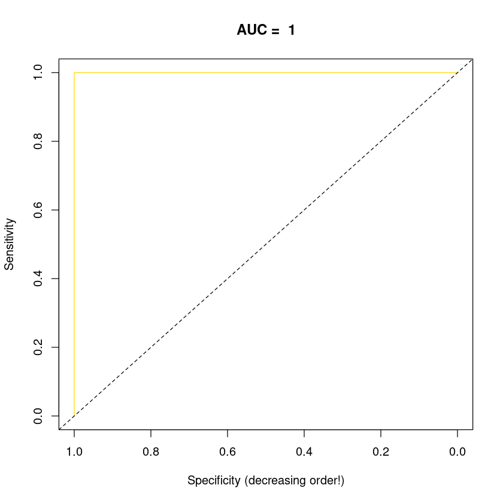

```r
### ROC Curve
trLogic = (yTst == 1)

ROCcrv = roc(response = trLogic, predictor = trhat)
AUC = auc(ROCcrv)

plot(x=ROCcrv$specificities,y=ROCcrv$sensitivities, main=paste("AUC = ",round(AUC,2)),
     xlab="Specificity (decreasing order!)", ylab="Sensitivity", xlim=c(1,0), type="l", col="gold")
abline(a=1,b=-1,lty="dashed")
```

```r
### Printing AUC
AUC
```

1

```r
### Creating yhat
yhatt = ifelse(trhat>0.5,"Yes","No")
```

```r
### Confusion Matrix
trtb = table(yhatt, yTst)
trtb
```

```
     yTst
yhatt   0   1
  No  652   2
  Yes   0  50
```

```r
### Checking the Accuracy
tracc = (trtb[1,1] + trtb[2,2]) / sum(trtb)
tracc
```

0.997159090909091

### What went wrong

While an accuracy of `0.99716` seems like we've createda perfect model, it is actually quite deceptive. Much like our `0.09750` accuracy score for the full data set indicated a too small data set, the accuracy score of `0.99716` also indicates our data set is unbalanced. So what wel will do is set aside a balnaced data set for our test data. This test data set will have 100 nonbankrupt companies (0) and 50 bankrupt companies (1) and we will use that to test our model.

```r
### Separating the bankrupt and nonbankrupt companies
nbr = list()
brp = list()

nbr = which(newbnk$Bankrupt == 0)
brp = which(newbnk$Bankrupt == 1)
```

```r
### Creating the new samples
set.seed(107)

bnrsamp = sample(nbr, size = (length(nbr) - 100), replace = FALSE)
brpsamp = sample(brp, size = (length(brp) - 50), replace = FALSE)
```

```r
### Creating the training and test sets
nwtrn = newbnk[c(bnrsamp, brpsamp), ]
nwtst = newbnk[-c(bnrsamp, brpsamp), ]
```

```r
### Checking our test data frame
table(nwtst$Bankrupt)
```

```
  0   1
100  50
```

```r
### Creating the new model matrix
mtt = model.matrix( ~ ., data = nwtrn)[, -1]
```

```r
### Logistic regression
nwfit = cv.glmnet(mtr, tnr$Bankrupt, family = "binomial", nfolds = 10, alpha = 0)
```

```r
### Getting predictions
predict(object = nwfit, type = "coefficients")
```

```
97 x 1 sparse Matrix of class "dgCMatrix"
                                                           lambda.1se
(Intercept)                                              8.509933e+00
ROA.C..before.interest.and.depreciation.before.interest -1.116067e+00
ROA.A..before.interest.and...after.tax                  -9.716522e-01
ROA.B..before.interest.and.depreciation.after.tax       -1.100525e+00
Operating.Gross.Margin                                  -1.339977e-01
Realized.Sales.Gross.Margin                             -8.349779e-02
Operating.Profit.Rate                                    1.280124e+00
Pre.tax.net.Interest.Rate                                4.482026e-01
After.tax.net.Interest.Rate                              3.339072e-01
Non.industry.income.and.expenditure.revenue             -1.990604e-01
Continuous.interest.rate..after.tax.                     3.518190e-01
Operating.Expense.Rate                                   5.030091e-12
Research.and.development.expense.rate                   -1.753745e-12
Cash.flow.rate                                          -3.908630e-01
Interest.bearing.debt.interest.rate                     -2.558039e-10
Tax.rate..A.                                            -2.277530e-01
Net.Value.Per.Share..B.                                 -1.551117e+00
Net.Value.Per.Share..A.                                 -1.522202e+00
Net.Value.Per.Share..C.                                 -1.488779e+00
Persistent.EPS.in.the.Last.Four.Seasons                 -3.048866e+00
Cash.Flow.Per.Share                                     -2.264172e+00
Revenue.Per.Share..Yuan...                              -7.771691e-11
Operating.Profit.Per.Share..Yuan...                     -1.399362e+00
Per.Share.Net.profit.before.tax..Yuan...                -2.485018e+00
Realized.Sales.Gross.Profit.Growth.Rate                  7.329575e+00
Operating.Profit.Growth.Rate                            -8.501499e-01
After.tax.Net.Profit.Growth.Rate                         5.508091e-01
Regular.Net.Profit.Growth.Rate                           6.378102e-01
Continuous.Net.Profit.Growth.Rate                       -2.470553e+01
Total.Asset.Growth.Rate                                 -2.023067e-12
Net.Value.Growth.Rate                                    3.419712e-11
Total.Asset.Return.Growth.Rate.Ratio                    -2.886950e-01
Cash.Reinvestment..                                      4.508857e-01
Current.Ratio                                           -9.063008e-01
Quick.Ratio                                             -8.784475e-11
Interest.Expense.Ratio                                   1.169318e+00
Total.debt.Total.net.worth                               1.872521e-10
Debt.ratio..                                             2.542290e+00
```

[output cut: 44 more lines]

```
CFO.to.Assets                                           -1.325588e-01
Cash.Flow.to.Equity                                      1.581646e+00
Current.Liability.to.Current.Assets                      1.540068e+00
Liability.Assets.Flag                                    2.555339e-01
Net.Income.to.Total.Assets                              -1.288140e+00
Total.assets.to.GNP.price                                3.221824e-11
No.credit.Interval                                      -3.381681e-01
Gross.Profit.to.Sales                                   -1.382901e-01
Net.Income.to.Stockholder.s.Equity                      -2.770790e-01
Liability.to.Equity                                      6.416484e-01
Degree.of.Financial.Leverage..DFL.                       7.166705e-01
Interest.Coverage.Ratio..Interest.expense.to.EBIT.       3.374450e-01
Net.Income.Flag                                          .
Equity.to.Liability                                     -3.274417e-01
Bankrupt1                                                5.116916e+00
```

```r
### Checking the coefficients
all(coef(nwfit) == predict(object = nwfit, type="coefficients"))
```

TRUE

```r
### Getting predictions
yst = nwtst$Bankrupt

newmatt = model.matrix( ~ ., data = nwtst)[,-1]

nwhat = predict(object = nwfit, newx = newmatt, type="response")

length(nwhat)
dim(newmatt)
```

150

1. 150

2. 96

```
Warning message in roc.default(response = nwLogic, predictor = nwhat):
“Deprecated use a matrix as predictor. Unexpected results may be produced, please pass a numeric vector.”
```

[figure not shown]

```r
### ROC Curve
nwLogic = (yst == 1)

crv = roc(response = nwLogic, predictor = nwhat)
AUC = auc(crv)

plot(x=ROCcrv$specificities,y=ROCcrv$sensitivities, main=paste("AUC = ",round(AUC,2)),
     xlab="Specificity (decreasing order!)", ylab="Sensitivity", xlim=c(1,0), type="l", col="dodgerblue")
abline(a=1,b=-1,lty="dashed")
```

```r
### Printing AUC
AUC
```

0.5459

```r
### Creating yhat
yhat = ifelse(nwhat>0.5,"Yes","No")
```

```r
### Confusion Matrix
nwtb = table(yhat, yst)
nwtb
```

```
     yst
yhat   0  1
  No  54 20
  Yes 46 30
```

```r
### Checking accuracy
ac = (nwtb[1, 1] + nwtb[2, 2]) / sum(nwtb)
ac
```

0.56

### Conclusion

So while we are able to create a model with good accuracy using naive bayes classification. Logistic classification gave us a model that was no more accurate than a coin flip. However, using logistic classification wasn't the wrong thing to do. We have to test multiple different ways to build models in order to figure out which ways works the best for our particular problem. In this case of course, naive bayes classification ended up being the best way to build this model.